# Analysis of Portland Jetport Historical Weather Data

# Install Libraries

```r
library(tidyverse)
library(readr)
library(ggthemes)
library(extrafont)
```

# Set Graphic Defaults

This code block calls a script that establishes defaults for a consistent Casco Bay State of the Bay graphics look and feel. It establishes cbep_colors, cbep_colors2, and theme_cbep, after loading selected fonts. IF you do not run this code, you will need to define those names somewhere else, or remove references to them in the remaintder of the code.

```r
sibfldnm <- 'Graphics'
parent <- dirname(getwd())
sibling <- paste(parent,sibfldnm, sep = '/')
fn <- 'CBEPGraphicsSetup.R'
source(paste(sibling,fn, sep = '/'))
```

```
[1] "Colors..."
[1] "Fonts..."
```

[output not shown]

```r
rm(sibfldnm, parent, sibling, fn)
```

# Read Data

```r
sibfldnm <- 'Original Data'
parent <- dirname(getwd())
sibling <- paste(parent,sibfldnm, sep = '/')
fn <- 'longannualdata.csv'
longannualdata <- read_csv(paste(sibling,fn, sep = '/')) %>%
  select(-station) %>%
  mutate(year = as.numeric(format(date, format='%Y'))) %>%
  mutate(cyear = year-1980)
```

Making sense of that data requires looking at the metadata, but here’s a list of the datatypes included.

```r
levels(factor(longannualdata$datatype))
```

[output not shown]

And their frequencies. Most data records are available for all years, A handful, mostly wind related, are inly available more recently.

```r
longannualdata %>%
  group_by(datatype) %>%
  summarize(n=n())
```

| datatype | n |
| --- | --- |
| AWND | 36 |
| CDSD | 79 |
| CLDD | 79 |
| DP01 | 79 |
| DP10 | 79 |
| DP1X | 79 |
| DSND | 74 |
| DSNW | 78 |
| DT00 | 79 |
| DT32 | 79 |

[output cut: 37 more lines]

# Annual Minimum, Maximum and Average Temperature

Codes for Key Temperature records in the downloaded annual data are: TAVG – Annual Average Temperature (unweighted; effectively average of monthly averages, of daily maxes and mins. Note that this means this is not indpendent of the other two metrics.) EMXT – Extreme Maximum Annual Temperature EMNT – Extreme Minimum Temperature

Note that in 2015 State of the Bay, we calculated our own annual means, mins and maxes from the daily records.

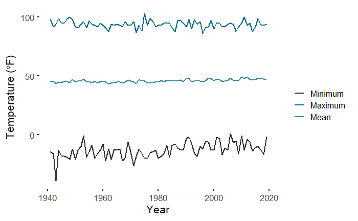

```r
tdata <- longannualdata %>%
  filter(datatype %in% c('TAVG', 'EMXT', 'EMNT')) %>%
  mutate(value = value*(9/5)+32)
plt <- ggplot(tdata, aes(year, value, color=datatype)) + geom_line(size=1) +
  xlab('Year') +
  theme_cbep() +
  ylab (expression('Temperature ('*~degree*F*')')) +
  scale_color_manual(values =cbep_colors2, name = '', labels = c('Minimum', 'Maximum', 'Mean'))
plt
```

It’s even uglier with the default cbep_colors. Or perhaps we should reverese those colors and use yellow, green, midblue?